# COMPUTATIONAL COGNITIVE SCIENCE

# Parameter Fitting

`Look at the resulting parameters and try to answer the following questions`

### Rescorla-Wagner

```python
bics_rw_slow, optimal_model_params_rw_slow, optimal_error_rw_slow = optimise(RescorlaWagner, ((0, 1, 0.1),), conditions={'slow': 1})
```

```python
bics_rw_fast, optimal_model_params_rw_fast, optimal_error_rw_fast = optimise(RescorlaWagner, ((0, 1, 0.1),), conditions={'slow': 0})
```

#### Does time pressure lead to slower learning?

Compare learning rate in slow vs fast tasks.

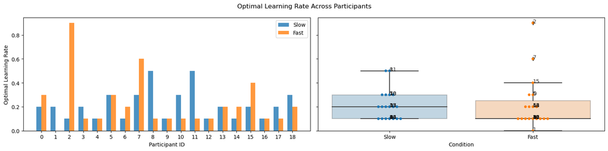

```python
st.ttest_rel(optimal_model_params_rw_slow[:18, 0], optimal_model_params_rw_fast[:18, 0])
```

$t$-Test for Paired Samples.  
❌ **Statistically insignificant.** Time-pressure doesn't affect learning ($p$ = 0.862).

#### Does time pressure lead to more noisy decisions?

Compare $\epsilon$-error parameter in slow vs fast tasks.

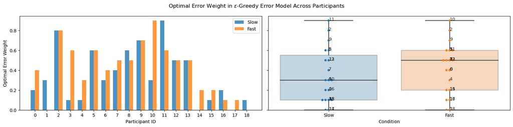

```python
st.ttest_rel(optimal_error_rw_slow[:18], optimal_error_rw_fast[:18])
```

$t$-Test for Paired Samples.  
❌ **Statistically insignificant.** Time-pressure doesn't affect noisiness of decisions ($p$ = 0.195).

##### Does time pressure lead to more noisy decisions for low number of features?

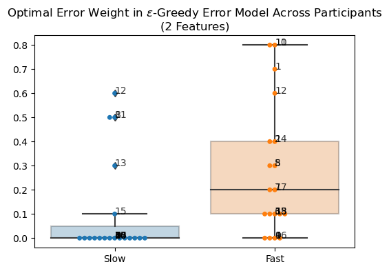

```python
st.ttest_rel(optimal_error_rw_slow_2[:18], optimal_error_rw_fast_2[:18])
```

$t$-Test for Paired Samples.  
✔️ **Statistically significant.** Time pressure affects noisiness of decisions for two features ($df$ = 17, $t$ = -2.667, $p$ = 0.016).

### Kalman Filter

```python
bics_kf_slow, optimal_model_params_kf_slow, optimal_error_kf_slow = optimise(KalmanFilter, ((0.1, 1, 0.1), (0.1, 1, 0.1)), conditions={'slow': 1})
```

```python
bics_kf_fast, optimal_model_params_kf_fast, optimal_error_kf_fast = optimise(KalmanFilter, ((0.1, 1, 0.1), (0.1, 1, 0.1)), conditions={'slow': 0})
```

#### Does time pressure lead to slower learning?

Compare $\sigma_y$ in slow vs fast tasks.

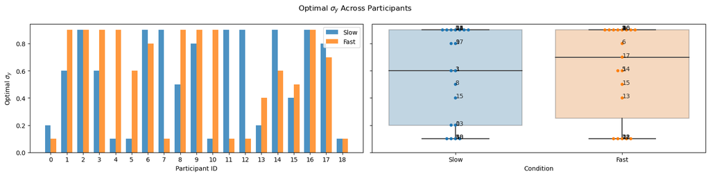

```python
st.ttest_rel(optimal_model_params_kf_slow[:18, 0], optimal_model_params_kf_fast[:18, 0])
```

$t$-Test for Paired Samples.  
❌ **Statistically insignificant.** Time-pressure doesn't affect learning ($p$ = 0.810).

#### Does time pressure lead to more noisy decisions?

Compare $\epsilon$-error parameter in slow vs fast tasks.

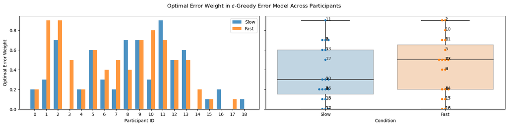

```python
st.ttest_rel(optimal_error_kf_slow[:18], optimal_error_kf_fast[:18])
```

$t$-Test for Paired Samples.  
❌ **Statistically insignificant.** Time-pressure doesn't affect noisiness of decisions ($p$ = 0.129).

### Random Model

```python
# bics_rm = np.array([bic(0, NUM_TRIALS*data['global_task'].nunique(), NUM_TRIALS*data['global_task'].nunique()*np.log(0.5))] * NUM_PARTICIPANTS)
```

```python
bics_rm_slow = np.array([bic(0, NUM_TRIALS*data[data['slow'] == 1]['global_task'].nunique(), NUM_TRIALS*data[data['slow'] == 1]['global_task'].nunique()*np.log(0.5))] * NUM_PARTICIPANTS)
```

```python
bics_rm_fast = np.array([bic(0, NUM_TRIALS*data[data['slow'] == 0]['global_task'].nunique(), NUM_TRIALS*data[data['slow'] == 0]['global_task'].nunique()*np.log(0.5))] * NUM_PARTICIPANTS)
```

# Model Comparison

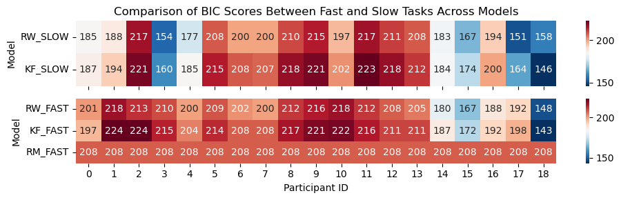

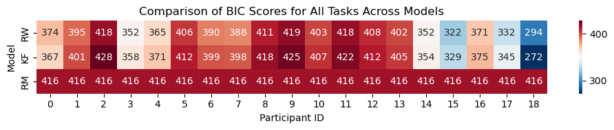

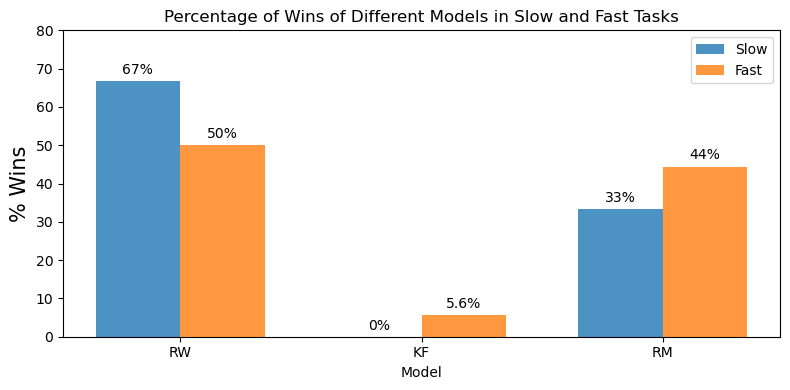

#### Does time pressure lead to simpler learning strategies?

Increased Time Pressure → Increased Random Decisions

#### Which model explains the human data best?

**Rescorla Wagner** > Random Model >> Kalman Filter

#### `Participant 18`

Kalman Filter Atypically Performs Best!

Participant was a bot actually using Kalman Filter to learn.

BIC score is not too low for an ideal learner?!

Some artificial randomness added for realism.  
Also, $\epsilon \neq 0$.

| Parameters | $\sigma_y$ | $\sigma_w$ |
| --- | --- | --- |
| Actual | 0.1 | 1.0 |
| Recovered | 0.1 | 0.9 |

# Additional Analysis

#### Does increasing the number of features lead to slower learning in regular (slow) tasks?

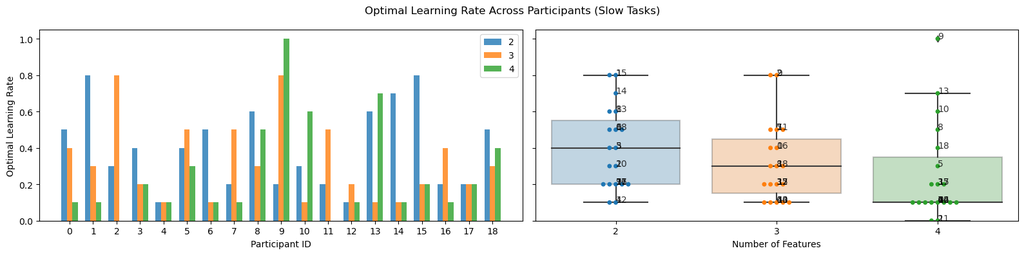

```python
smf.mixedlm(formula='learning_rate ~ num_features', groups='participant_id', ...).fit()
```

Linear Mixed Effects Model Analysis.  
❌ **Statistically insignificant.** Number of features doesn't affect learning ($\beta$ = -0.072, Marginal $R^2$ = 0.057, $p$ = 0.073).  
Increasing features might lead to slower learning.

#### Does increasing the number of features lead to slower learning under time pressure (in fast tasks)?

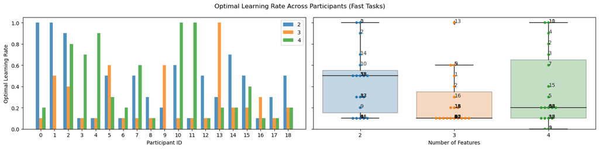

```python
smf.mixedlm(formula='learning_rate ~ num_features', groups='participant_id', ...).fit()
```

Linear Mixed Effects Model Analysis.  
❌ **Statistically insignificant.** Number of features doesn't affect learning ($p$ = 0.632).

#### Does increasing the number of features lead to noisy decisions in regular (slow) tasks?

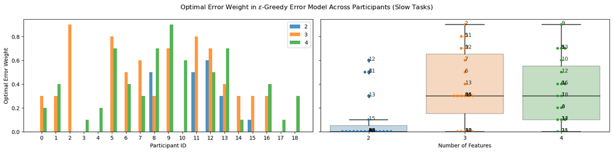

```python
fig, ax = plt.subplots(1,2, figsize=(16, 4), sharey=True)

fig.suptitle(r'Optimal Error Weight in $\epsilon$-Greedy Error Model Across Participants (Slow Tasks)')
ax[0].bar(PARTICIPANTS - 0.23, optimal_error_rw_slow_2, 0.23, label='2', alpha=0.8)
ax[0].bar(PARTICIPANTS, optimal_error_rw_slow_3, 0.23, label='3', alpha=0.8)
ax[0].bar(PARTICIPANTS + 0.23, optimal_error_rw_slow_4, 0.23, label='4', alpha=0.8)
ax[0].set_xticks(PARTICIPANTS)
ax[0].legend()
ax[0].set_xlabel('Participant ID')
ax[0].set_ylabel('Optimal Error Weight')

boxplots([optimal_error_rw_slow_2, optimal_error_rw_slow_3, optimal_error_rw_slow_4], ('2', '3', '4'), ax[1])
ax[1].set_xlabel('Number of Features')
plt.tight_layout()
```

```python
smf.mixedlm(formula='epsilon_error ~ num_features', groups='participant_id', ...).fit()
```

Linear Mixed Effects Model Analysis.  
✔️ **Statistically significant.** Number of features affects noisiness of decisions ($\beta$ = 0.119, Marginal $R^2$ = 0.146, $p$ = 0.005), with the addition of each feature increasing noisiness on average by 0.119.

##### Tukey's Honestly Significant Difference Test

Multiple Comparison of Means - Tukey HSD, FWER=0.05

| group1 | group2 | meandiff | p-adj | lower | upper | reject |
| --- | --- | --- | --- | --- | --- | --- |
| 2 | 3 | 0.2889 | 0.0055 | 0.075 | 0.5028 | True |
| 2 | 4 | 0.2389 | 0.0252 | 0.025 | 0.4528 | True |
| 3 | 4 | -0.05 | 0.8396 | -0.2639 | 0.1639 | False |

*Participants make more random decisions for features greater than two in (slow) tasks.*

#### Does increasing the number of features lead to noisy decisions under time pressure (in fast tasks)?

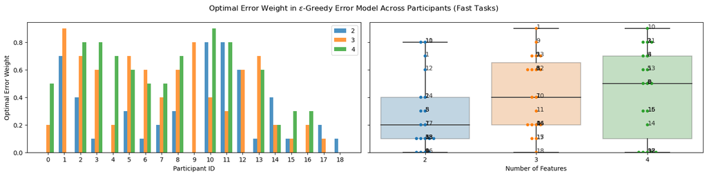

```python
smf.mixedlm(formula='epsilon_error ~ num_features', groups='participant_id', ...).fit()
```

Linear Mixed Effects Model Analysis.  
❌ **Statistically insignificant.** Number of features doesn't affect noisiness of decisions ($\beta$ = 0.086, Marginal $R^2$ = 0.075, $p$ = 0.057).  
Increasing features might lead to noisier decisions.

# Conclusions

**Performance above chance level** ($t$ = 9.75, $p$ < 0.05), with an average accuracy of 63.3%.

**Performance improves over trials within task** ($\beta$ = 0.014, $R^2$ = 0.007, $p$ < 0.001), on average 1.4% better each trial after the first.

**Performance doesn't really improve over rounds** ($p$ = 0.242).

**Higher reaction time generally resulted in better accuracy** ($\beta$ = 0.00005, $R$ = 0.011, $p$ < 0.001), with a 0.5% increase in accuracy for every 100ms.

**But, an additional Pearson's correlation test suggested no statistically significant relationship** ($r$ = -0.43, $p$ = 0.07).

Increased Time Pressure → Increased Random Decisions

**Rescorla Wagner** > Random Model >> Kalman Filter

**Time pressure significantly affects noisiness of decisions for two features** (paired-samples, $t(17)$ = -2.667, $p$ = 0.016).

**Performance decreases with additional features** ($\beta$ = -0.043, $R^2$ = 0.005, $p$ < 0.001), with the addition of each feature decreasing accuracy on average by 4.3%.

**Increasing features might lead to slower learning in regular (slow) tasks** ($\beta$ = -0.072, Marginal $R^2$ = 0.057, $p$ = 0.073).

**Increasing features leads to noisier decisions in regular (slow) tasks** ($\beta$ = 0.119, Marginal $R^2$ = 0.146, $p$ = 0.005), with the addition of each feature increasing noisiness on average by 0.119.

**Increasing features might lead to noisier decisions under time pressure (in fast tasks)** ($\beta$ = 0.086, Marginal $R^2$ = 0.075, $p$ = 0.057).

# Potential Improvements

- Modelling Improvements
  - More advanced models can be added (Heuristics, Neural Networks, Exemplar-Based Models, Gaussin Process).
  - Compare different decision making rules (Accuracy Maximisation, Probability Matching, Sample Based Rules, Drift Diffusion Models, Resource-rational Models)
  - Increase search space for parameter fitting.
- Other Analyses
  - Does doing slow tasks first lead to better performance in subsequent fast tasks?
  - ...

# References

Binz, M., Gershman, S.J., Schulz, E. and Endres, D., 2022. Heuristics from bounded meta-learned inference. *Psychological review.*

Schulz, E., Speekenbrink, M. and Krause, A., 2018. A tutorial on Gaussian process regression: Modelling, exploring, and exploiting functions. *Journal of Mathematical Psychology, 85, pp.1-16.*

Wu, C.M., Schulz, E., Gerbaulet, K., Pleskac, T.J. & Speekenbrink, M. (2019). Under pressure: The influence of time limits on human exploration. *Proceedings of the 41st Annual Conference of the Cognitive Science Society.*

# Questions?

Thank You!